# Lectures 5 & 6 — Multi-State Life Tables

Author

Dr Belen Zapata-Diomedi, IMS Epidemiology Unit

Published

April 2, 2026

# 1 Data and Functions

Here we load the libraries, source the helper functions, and read all required data.

```r
# remotes::install_github("meta-analyses/drpa")
library(drpa)
library(tidyverse) # ggplot2, dplyr, tidyr, readr, stringr
# ── Helper functions (RunLifeTable, assignPA_RRs, calculate_pif) ───────────────
source("functions.R")

# ── Output directory ───────────────────────────────────────────────────────────
dir.create("outputs/lecture_5_6", recursive = TRUE, showWarnings = FALSE)
```

## 1.1 MSLT data (Colombia)

The MSLT data file contains one row per age (0–100) and sex, with all-cause mortality rates (`mx`), disability weights (`pyld_rate`), population size, and disease-specific parameters for Colombia. All rates are derived from GBD 2019 Colombia estimates.

```r
mslt_general <- read_csv("data/lecture_5_6/mslt_colombia.csv")

## change to population for Bogota, file has population for Colombia.

population_bogota <- read_csv("data/lecture_5_6/population_bogota.csv") %>%
  mutate(age = min_age + 2)

# Replace population in mslt_general with Bogotá population
mslt_general <- mslt_general %>%
  dplyr::select(-population) %>%
  left_join(
    population_bogota %>% dplyr::select(sex, age, population),
    by = c("sex", "age"))

glimpse(mslt_general)
```

```
Rows: 202
Columns: 27
$ age                <dbl> 0, 1, 2, 3, 4, 5, 6, 7, 8, 9, 10, 11, 12, 13, 14, 1…
$ sex                <chr> "female", "female", "female", "female", "female", "…
$ age_sex            <chr> "0_female", "1_female", "2_female", "3_female", "4_…
$ mx                 <dbl> 0.0002134483, 0.0002218894, 0.0002306645, 0.0002397…
$ pyld_rate          <dbl> 0.04471625, 0.04634719, 0.04803763, 0.04978972, 0.0…
$ deaths_rate_ishd   <dbl> 1.213285e-06, 1.326424e-06, 1.450114e-06, 1.585338e…
$ ylds_rate_ishd     <dbl> 1.914479e-06, 2.288910e-06, 2.736573e-06, 3.271789e…
$ dw_adj_ishd        <dbl> 0.06165483, 0.06113510, 0.06061974, 0.06010873, 0.0…
$ prevalence_ishd    <dbl> 3.185404e-05, 3.854422e-05, 4.663950e-05, 5.643500e…
$ deaths_rate_copd   <dbl> 4.441643e-07, 4.735316e-07, 5.048406e-07, 5.382196e…
$ ylds_rate_copd     <dbl> 1.973456e-05, 2.144813e-05, 2.331050e-05, 2.533457e…
$ dw_adj_copd        <dbl> 0.05656653, 0.05679289, 0.05702016, 0.05724834, 0.0…
$ prevalence_copd    <dbl> 0.0003578896, 0.0003887913, 0.0004223612, 0.0004588…
$ deaths_rate_dmt2   <dbl> 7.319224e-07, 7.766747e-07, 8.241632e-07, 8.745554e…
$ ylds_rate_dmt2     <dbl> 5.542206e-05, 6.260569e-05, 7.072043e-05, 7.988699e…
$ dw_adj_dmt2        <dbl> 0.04086845, 0.04170162, 0.04255177, 0.04341926, 0.0…
$ prevalence_dmt2    <dbl> 0.001391155, 0.001545546, 0.001717071, 0.001907631,…
$ case_fatality_copd <dbl> 0.03434298, 0.03222743, 0.03122278, 0.03033946, 0.0…
$ case_fatality_dmt2 <dbl> 0.069564965, 0.052285300, 0.044712145, 0.038806345,…
$ case_fatality_ishd <dbl> 0.08993944, 0.08329171, 0.07912450, 0.07564536, 0.0…
$ incidence_copd     <dbl> 4.601195e-05, 5.288841e-05, 5.701618e-05, 6.137867e…
$ incidence_dmt2     <dbl> 5.001610e-05, 7.790991e-05, 9.688934e-05, 1.212964e…
$ incidence_ishd     <dbl> 5.731339e-05, 6.424151e-05, 6.790344e-05, 7.183344e…
$ remission_copd     <dbl> 0, 0, 0, 0, 0, 0, 0, 0, 0, 0, 0, 0, 0, 0, 0, 0, 0, …
$ remission_dmt2     <dbl> 0, 0, 0, 0, 0, 0, 0, 0, 0, 0, 0, 0, 0, 0, 0, 0, 0, …
$ remission_ishd     <dbl> 0, 0, 0, 0, 0, 0, 0, 0, 0, 0, 0, 0, 0, 0, 0, 0, 0, …
$ population         <dbl> NA, NA, NA, NA, NA, NA, NA, NA, NA, NA, NA, NA, NA,…
```

## 1.2 Bogotá population data

This file contains the Bogotá study population with marginal MET-hours baseline and pedestrian scenario created in lecture 3 and saved in lecture_5_6 data.

```r
io <- readRDS("data/lecture_3/ithim_io/io.rds")
base_pop <- io$bogota$base_pop
travel_mmets <- read_csv("data/lecture_5_6/mmets_bogota.csv")

bogota_mmets <- travel_mmets %>%
  left_join(base_pop %>% dplyr::select(participant_id, age, sex, age_cat),
            by = "participant_id") %>%
  dplyr::select(participant_id, baseline, sc_ped, age, sex, age_cat)

bogota_mmets_long <- bogota_mmets %>%
  pivot_longer(cols = c(baseline, sc_ped), names_to = "scenario", values_to = "total_mmets")

bogota_mmets_long %>%
  group_by(sex, scenario) %>%
  summarise(
    n      = dplyr::n(),
    min    = round(min(total_mmets,     na.rm = TRUE), 2),
    q1     = round(quantile(total_mmets, 0.25,  na.rm = TRUE), 2),
    median = round(median(total_mmets,  na.rm = TRUE), 2),
    mean   = round(mean(total_mmets,    na.rm = TRUE), 2),
    q3     = round(quantile(total_mmets, 0.75,  na.rm = TRUE), 2),
    max    = round(max(total_mmets,     na.rm = TRUE), 2),
    .groups = "drop"
  )
```

```
# A tibble: 4 × 9
  sex    scenario     n   min    q1 median  mean    q3   max
  <chr>  <chr>    <int> <dbl> <dbl>  <dbl> <dbl> <dbl> <dbl>
1 female baseline 55593     0     0   11.1  11.6  17.5  128.
2 female sc_ped   55593     0     0   11.4  11.9  17.8  129.
3 male   baseline 52825     0     0   14.7  15.3  22.3  136.
4 male   sc_ped   52825     0     0   14.8  15.5  22.7  136.
```

# 2 Life Tables

A **cohort life table** tracks a group of people born (or entering an age) at the same time and follows them as they age and die. Each row represents one year of age.

| Variable | Meaning |
| --- | --- |
| `mx` | All-cause mortality *rate* at age x (deaths per person-year) |
| `qx` | Probability of dying between age x and x+1 |
| `lx` | Number of survivors at age x |
| `dx` | Number who die between age x and x+1 |
| `Lx` | Person-years lived by the cohort between age x and x+1 |
| `ex` | Remaining life expectancy at age x |
| `pyld_rate` | All-cause disability weight (proportion of health lost) |
| `Lwx` | Health-adjusted person-years lived (Lx × (1 − pyld_rate)) |
| `ewx` | Health-adjusted life expectancy at age x |

The key relationships are:

$$q_x = 1 - e^{-m_x}$$

$$L_x = \frac{l_x + l_{x+1}}{2}$$

$$e_x = \frac{\sum_{t=x}^{100} L_t}{l_x}$$

## 2.1 Reference life table (no trend)

Available mid-ages: 17, 22, 27, 32, 37, 42, 47, **52**, 57, 62, 67, 72, 77, 82, 87, 92, 97

```r
lt_ref <- RunLifeTable(
  in_data    = mslt_general,
  in_sex     = "female",
  in_mid_age = 37,
  mx_trend   = NA,   # NA = no trend, use static mx
  scenario   = 0     # 0 = no PIF-based reduction
) %>%
  mutate(label = "Reference (no trend)")

write_csv(lt_ref, "outputs/lecture_5_6/life_table_reference.csv")

lt_ref %>%
  dplyr::select(age, mx, qx, lx, dx, Lx, ex, Lwx, ewx) %>%
  head(10)
```

```
# A tibble: 10 × 9
     age       mx       qx      lx    dx      Lx    ex     Lwx   ewx
   <dbl>    <dbl>    <dbl>   <dbl> <dbl>   <dbl> <dbl>   <dbl> <dbl>
 1    37 0.000971 0.000970 309304   300. 309154.  47.3 266809.  37.9
 2    38 0.00103  0.00103  309004.  318. 308845.  46.4 266005.  37.0
 3    39 0.00109  0.00109  308686.  336. 308518.  45.4 265216.  36.2
 4    40 0.00116  0.00116  308350.  357. 308171.  44.4 264423.  35.4
 5    41 0.00123  0.00123  307993.  379. 307803.  43.5 263608.  34.6
 6    42 0.00131  0.00131  307614.  404. 307412.  42.6 262750.  33.8
 7    43 0.00141  0.00140  307210.  432. 306994.  41.6 261840.  33.0
 8    44 0.00151  0.00151  306779.  463. 306547.  40.7 260886.  32.2
 9    45 0.00162  0.00162  306316.  497. 306067.  39.7 259897.  31.3
10    46 0.00175  0.00175  305819.  534. 305552.  38.8 258881.  30.5
```

```r
cat(sprintf("Remaining life expectancy at age 37 (female): %.2f years\n",
            lt_ref$ex[1]))
```

```
Remaining life expectancy at age 37 (female): 47.30 years
```

```r
cat(sprintf("Health-adjusted life expectancy at age 37:    %.2f years\n",
            lt_ref$ewx[1]))
```

```
Health-adjusted life expectancy at age 37:    37.87 years
```

```r
cat(sprintf("\nTotal person-years lived by cohort (sum Lx):  %s\n",
            format(round(sum(lt_ref$Lx)), big.mark = ",")))
```

```
Total person-years lived by cohort (sum Lx):  14,631,587
```

```r
cat(sprintf("Total health-adjusted life years  (sum Lwx):  %s\n",
            format(round(sum(lt_ref$Lwx)), big.mark = ",")))
```

```
Total health-adjusted life years  (sum Lwx):  11,713,844
```

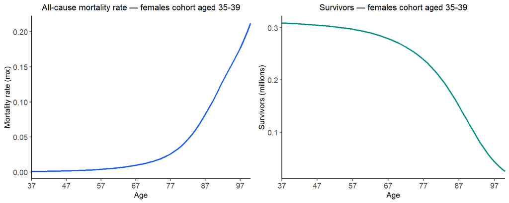

Reference life table for females cohort aged 35-39. Left: all-cause mortality rate rising with age. Right: cohort survivors declining over time.

```r
p1 <- ggplot(lt_ref, aes(x = age, y = mx)) +
  geom_line(colour = "#2563EB", linewidth = 1) +
  scale_x_continuous(limits = c(37, 100), breaks = seq(37, 100, 10),
                     expand = c(0, 0)) +
  labs(title = "All-cause mortality rate — females cohort aged 35-39",
       x = "Age", y = "Mortality rate (mx)") +
  theme_classic() +
  theme(plot.title = element_text(size = 12, hjust = 0.5),
        axis.text  = element_text(size = 11),
        axis.title = element_text(size = 11))

p2 <- ggplot(lt_ref, aes(x = age, y = lx / 1e6)) +
  geom_line(colour = "#0D9488", linewidth = 1) +
  scale_x_continuous(limits = c(37, 100), breaks = seq(37, 100, 10),
                     expand = c(0, 0)) +
  labs(title = "Survivors — females cohort aged 35-39",
       x = "Age", y = "Survivors (millions)") +
  theme_classic() +
  theme(plot.title = element_text(size = 12, hjust = 0.5),
        axis.text  = element_text(size = 11),
        axis.title = element_text(size = 11))

gridExtra::grid.arrange(p1, p2, ncol = 2)
```

## 2.2 What if mortality improves over time?

The reference life table above uses **static** mortality rates — the same `mx` at every age, regardless of which calendar year the cohort reaches that age. This is a simplification. In reality, mortality rates change over time as healthcare, living standards, and disease management improve (or worsen).

### 2.2.1 How the trend is modelled

The `mx_trend` argument applies an **annual percentage change** that **compounds** across simulation years. Because each row of the life table represents the cohort one year older — and therefore one calendar year further into the future — the multiplier accumulates:

$$m_x^{\text{projected}} = m_x \times \left(1 - \frac{\text{trend}}{100}\right)^{t-1}$$

where $t = 1$ at cohort entry (no change), $t = 2$ one year later, and so on.

### 2.2.2 Running the life table with a 0.5% annual trend

```r
lt_trend <- RunLifeTable(
  in_data    = mslt_general,
  in_sex     = "female",
  in_mid_age = 37,
  mx_trend   = 0.5, # 0.5% annual reduction in mx, compounding each year
  mx_trend_years = 10,
  scenario   = 0
) %>%
  mutate(label = "With trend (−0.5%/yr)")

write_csv(lt_trend, "outputs/lecture_5_6/life_table_trend.csv")
```

### 2.2.3 Comparing reference vs trend

```r
gain_ly_trend  <- sum(lt_trend$Lx)  - sum(lt_ref$Lx)
gain_hly_trend <- sum(lt_trend$Lwx) - sum(lt_ref$Lwx)
gain_ex_trend  <- (lt_trend$ex[1]   - lt_ref$ex[1]) * 365

cat(sprintf("Difference in person-years lived (Lx):           %s\n",
            format(round(gain_ly_trend),  big.mark = ",")))
```

```
Difference in person-years lived (Lx):           138,130
```

```r
cat(sprintf("Difference in health-adjusted life years (Lwx):  %s\n",
            format(round(gain_hly_trend), big.mark = ",")))
```

```
Difference in health-adjusted life years (Lwx):  97,560
```

```r
cat(sprintf("Difference in life expectancy:                   %.1f days (%.2f years)\n",
            gain_ex_trend, gain_ex_trend / 365))
```

```
Difference in life expectancy:                   163.0 days (0.45 years)
```

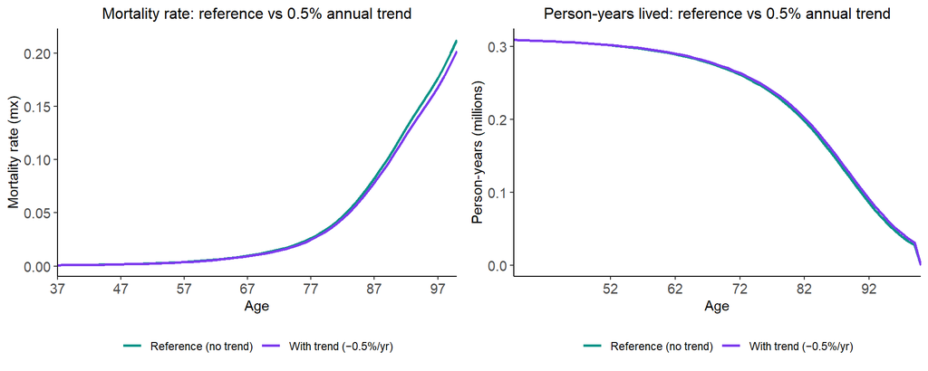

Effect of a 0.5% annual mortality reduction on the mortality rate trajectory (left) and cumulative person-years lived (right). The gap between curves widens with age as the compounding effect accumulates.

```r
lt_compare_trend <- bind_rows(lt_ref, lt_trend)

p_mx <- ggplot(lt_compare_trend, aes(x = age, y = mx, colour = label)) +
  geom_line(linewidth = 1) +
  scale_colour_manual(values = c("Reference (no trend)"    = "#0D9488",
                                 "With trend (−0.5%/yr)"   = "#7C3AED")) +
  scale_x_continuous(limits = c(37, 100), breaks = seq(37, 100, 10),
                     expand = c(0, 0)) +
  labs(title = "Mortality rate: reference vs 0.5% annual trend",
       x = "Age", y = "Mortality rate (mx)", colour = NULL) +
  theme_classic() +
  theme(plot.title = element_text(size = 12, hjust = 0.5),
        axis.text  = element_text(size = 11),
        axis.title = element_text(size = 11),
        legend.position = "bottom")

p_lx <- ggplot(lt_compare_trend, aes(x = age, y = Lx / 1e6, colour = label)) +
  geom_line(linewidth = 1) +
  scale_colour_manual(values = c("Reference (no trend)"    = "#0D9488",
                                 "With trend (−0.5%/yr)"   = "#7C3AED")) +
  scale_x_continuous(limits = c(37, 100), breaks = seq(52, 100, 10),
                     expand = c(0, 0)) +
  labs(title = "Person-years lived: reference vs 0.5% annual trend",
       x = "Age", y = "Person-years (millions)", colour = NULL) +
  theme_classic() +
  theme(plot.title = element_text(size = 12, hjust = 0.5),
        axis.text  = element_text(size = 11),
        axis.title = element_text(size = 11),
        legend.position = "bottom")

gridExtra::grid.arrange(p_mx, p_lx, ncol = 2)
```

| Scenario | Life expectancy | HA life expectancy | Sum Lx | Sum Lwx |
| --- | --- | --- | --- | --- |
| Reference (no trend) | 47.30 | 37.87 | 14,631,587 | 11,713,844 |
| With trend (−0.5%/yr) | 47.75 | 38.19 | 14,769,717 | 11,811,404 |
| Difference | 0.45 | 0.32 | 138,130 | 97,560 |

**Interpretation**

A 0.5% annual compound reduction in all-cause mortality adds approximately 138,130 person-years to this cohort over their remaining lifetime and increases life expectancy by about 163 days.

**Extending this**

`mx_trend` can also be **negative** to model worsening mortality (e.g. `mx_trend = -1` for a 1% annual increase).

# 3 Scenario 1 — Direct Mortality Reduction (5%)

**Question:** What is the gain in life years and life expectancy if all-cause mortality is reduced by 5% across all ages?

The `scenario` argument applies a one-off proportional reduction to `mx` at every age:

$$m_x^{\text{scenario}} = m_x \times (1 - \text{scenario})$$

This is distinct from `mx_trend`, which compounds year-on-year. The two can be combined: `scenario` captures a structural shift (e.g. from a policy intervention) while `mx_trend` captures background secular change.

```r
lt_sc5 <- RunLifeTable(
  in_data    = mslt_general,
  in_sex     = "female",
  in_mid_age = 37,
  mx_trend   = NA,
  scenario   = 0.05      # 5% one-off reduction at all ages
) %>%
  mutate(label = "5% mortality reduction")

write_csv(lt_sc5, "outputs/lecture_5_6/life_table_scenario_5pct.csv")
```

## 3.1 Comparing reference vs scenario

```r
gain_ly  <- sum(lt_sc5$Lx)  - sum(lt_ref$Lx)
gain_hly <- sum(lt_sc5$Lwx) - sum(lt_ref$Lwx)
gain_ex  <- (lt_sc5$ex[1]   - lt_ref$ex[1]) * 365

cat(sprintf("Gain in person-years lived (Lx):           %s\n",
            format(round(gain_ly),  big.mark = ",")))
```

```
Gain in person-years lived (Lx):           145,701
```

```r
cat(sprintf("Gain in health-adjusted life years (Lwx):  %s\n",
            format(round(gain_hly), big.mark = ",")))
```

```
Gain in health-adjusted life years (Lwx):  103,289
```

```r
cat(sprintf("Gain in life expectancy:                   %.1f days (%.2f years)\n",
            gain_ex, gain_ex / 365))
```

```
Gain in life expectancy:                   171.9 days (0.47 years)
```

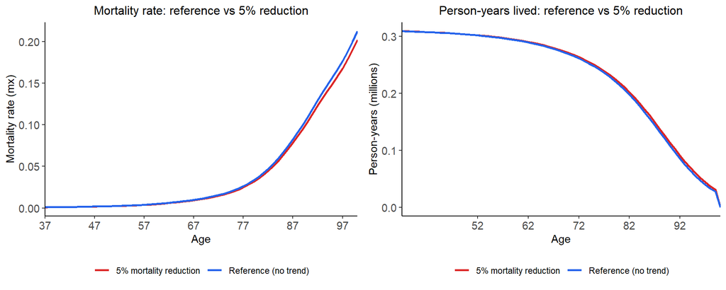

```r
lt_compare <- bind_rows(lt_ref, lt_sc5)

p3 <- ggplot(lt_compare, aes(x = age, y = mx, colour = label)) +
  geom_line(linewidth = 1) +
  scale_colour_manual(values = c("Reference (no trend)"   = "#2563EB",
                                 "5% mortality reduction" = "#DC2626")) +
  scale_x_continuous(limits = c(37, 100), breaks = seq(37, 100, 10),
                     expand = c(0, 0)) +
  labs(title = "Mortality rate: reference vs 5% reduction",
       x = "Age", y = "Mortality rate (mx)", colour = NULL) +
  theme_classic() +
  theme(plot.title = element_text(size = 12, hjust = 0.5),
        axis.text  = element_text(size = 11),
        axis.title = element_text(size = 11),
        legend.position = "bottom")

p4 <- ggplot(lt_compare, aes(x = age, y = Lx / 1e6, colour = label)) +
  geom_line(linewidth = 1) +
  scale_colour_manual(values = c("Reference (no trend)"   = "#2563EB",
                                 "5% mortality reduction" = "#DC2626")) +
  scale_x_continuous(limits = c(37, 100), breaks = seq(52, 100, 10),
                     expand = c(0, 0)) +
  labs(title = "Person-years lived: reference vs 5% reduction",
       x = "Age", y = "Person-years (millions)", colour = NULL) +
  theme_classic() +
  theme(plot.title = element_text(size = 12, hjust = 0.5),
        axis.text  = element_text(size = 11),
        axis.title = element_text(size = 11),
        legend.position = "bottom")

gridExtra::grid.arrange(p3, p4, ncol = 2)
```

## 3.2 Summary table — reference, trend, and scenario

| Scenario | Life expectancy | HA life expectancy | Sum Lx |
| --- | --- | --- | --- |
| Reference (no trend) | 47.30 | 37.87 | 14,631,587 |
| With trend (−0.5%/yr) | 47.75 | 38.19 | 14,769,717 |
| 5% mortality reduction | 47.78 | 38.21 | 14,777,287 |
| Difference (trend vs ref) | 0.45 | 0.32 | 138,130 |
| Difference (5% sc vs ref) | 0.47 | 0.33 | 145,701 |

**Scenario vs trend — a key teaching point**

Notice that in simulation using a cohort perspective (in this implementation include trends) is preferred since the aim is to simulate what would happen in the future under a counterfactual.

## 3.3 Example 2 — Physical Activity Increase (Bogotá)

**Question:** What is the gain in life years from a population-level increase in physical activity (pedestrian scenario) for the Bogotá population?

The pathway is:

$$\text{PA distribution} \xrightarrow{\text{dose-response}} \text{RR by individual} \xrightarrow{\text{PIF}} \Delta m_x \xrightarrow{\text{life table}} \Delta \text{life years}$$

## 3.4 Step 1 — Assign individual-level RRs

```r
diseases <- "all-cause-mortality"

bogota_ref  <- bogota_mmets_long %>%
  filter(scenario == "baseline") %>%
  rename(mmet = total_mmets) %>%
  assignPA_RRs(., diseases = diseases, mmet_col = "mmet")

bogota_scen <- bogota_mmets_long %>%
  filter(scenario == "sc_ped") %>%
  rename(mmet = total_mmets) %>%
  assignPA_RRs(., diseases = diseases, mmet_col = "mmet")

# Sanity check — RR should be <= 1
cat("Reference RR summary:\n")
```

```
Reference RR summary:
```

```r
summary(bogota_ref$`rr_PHYSICAL_ACTIVITY_all-cause-mortality`)
```

```
   Min. 1st Qu.  Median    Mean 3rd Qu.    Max.
 0.6755  0.6755  0.6851  0.8053  1.0000  1.0000
```

```r
cat("\nScenario RR summary (should be slightly lower):\n")
```

```
Scenario RR summary (should be slightly lower):
```

```r
summary(bogota_scen$`rr_PHYSICAL_ACTIVITY_all-cause-mortality`)
```

```
   Min. 1st Qu.  Median    Mean 3rd Qu.    Max.
 0.6755  0.6755  0.6836  0.8044  1.0000  1.0000
```

## 3.5 Step 2 — Calculate PIFs

$$\text{PIF} = \frac{\sum \text{RR}(\text{ref}) - \sum \text{RR}(\text{scen})}{\sum \text{RR}(\text{ref})}$$

```r
pif_results <- calculate_pif(pop_ref = bogota_ref, pop_scen = bogota_scen)
pifs        <- pif_results$pif_table

print(pifs, n = Inf)
```

```
# A tibble: 22 × 7
   sex    age_cat cause                   n sum_rr_ref sum_rr_scen      pif
   <chr>  <chr>   <chr>               <int>      <dbl>       <dbl>    <dbl>
 1 female 15-19   all_cause_mortality  6650      6081.       6080. 0.000139
 2 female 20-24   all_cause_mortality  5235      3818.       3816. 0.000642
 3 female 25-29   all_cause_mortality  5185      3763.       3760. 0.000708
 4 female 30-34   all_cause_mortality  5312      4227.       4220. 0.00171
 5 female 35-39   all_cause_mortality  5298      4192.       4185. 0.00167
 6 female 40-44   all_cause_mortality  5135      4077.       4070. 0.00173
 7 female 45-49   all_cause_mortality  5322      4230.       4223. 0.00159
 8 female 50-54   all_cause_mortality  4687      3796.       3787. 0.00238
 9 female 55-59   all_cause_mortality  4823      3913.       3905. 0.00223
10 female 60-64   all_cause_mortality  3903      3233.       3229. 0.00128
11 female 65-69   all_cause_mortality  4043      3348.       3343. 0.00150
12 male   15-19   all_cause_mortality  6671      6116.       6115. 0.000195
13 male   20-24   all_cause_mortality  5268      3843.       3840. 0.000854
14 male   25-29   all_cause_mortality  5182      3782.       3779. 0.000846
15 male   30-34   all_cause_mortality  4880      3909.       3903. 0.00158
16 male   35-39   all_cause_mortality  4947      3957.       3952. 0.00121
17 male   40-44   all_cause_mortality  5088      4046.       4040. 0.00153
18 male   45-49   all_cause_mortality  5023      4018.       4011. 0.00180
19 male   50-54   all_cause_mortality  4338      3509.       3507. 0.000633
20 male   55-59   all_cause_mortality  4187      3414.       3412. 0.000643
21 male   60-64   all_cause_mortality  3599      3007.       3005. 0.000519
22 male   65-69   all_cause_mortality  3642      3031.       3029. 0.000515
```

## 3.6 Step 3 — Run life table with PIF-modified mortality

$$m_x^{\text{PA scenario}} = m_x \times (1 - \text{PIF})$$

```r
lt_pa <- RunLifeTable(
  in_data    = mslt_general,
  in_sex     = "female",
  in_mid_age = 37,
  mx_trend   = NA,
  scenario   = pifs
) %>%
  mutate(label = "Walking sceneario")

write_csv(lt_pa, "outputs/lecture_5_6/life_table_pa_scenario.csv")
```

## 3.7 Step 5 — Compare reference vs pedestrian scenario

```r
gain_ly_pa  <- sum(lt_pa$Lx)  - sum(lt_ref$Lx)
gain_hly_pa <- sum(lt_pa$Lwx) - sum(lt_ref$Lwx)
gain_ex_pa  <- (lt_pa$ex[1]   - lt_ref$ex[1]) * 365

cat(sprintf("Gain in person-years lived (Lx):          %s\n",
            format(round(gain_ly_pa),  big.mark = ",")))
```

```
Gain in person-years lived (Lx):          1,764
```

```r
cat(sprintf("Gain in health-adjusted life years (Lwx): %s\n",
            format(round(gain_hly_pa), big.mark = ",")))
```

```
Gain in health-adjusted life years (Lwx): 1,350
```

```r
cat(sprintf("Gain in life expectancy:                  %.1f days\n",
            gain_ex_pa))
```

```
Gain in life expectancy:                  2.1 days
```

[figure not shown]

```r
lt_compare_pa <- bind_rows(lt_ref, lt_pa)

p5 <- ggplot(lt_compare_pa, aes(x = age, y = mx, colour = label)) +
  geom_line(linewidth = 1) +
  scale_colour_manual(values = c("Reference (no trend)"    = "#2563EB",
                                 "PA scenario (+2 mMETs)"  = "#D97706")) +
  scale_x_continuous(limits = c(37, 100), breaks = seq(37, 100, 10),
                     expand = c(0, 0)) +
  labs(title = "Mortality rate: reference vs PA scenario",
       x = "Age", y = "Mortality rate (mx)", colour = NULL) +
  theme_classic() +
  theme(plot.title = element_text(size = 12, hjust = 0.5),
        axis.text  = element_text(size = 11),
        axis.title = element_text(size = 11),
        legend.position = "bottom")

p6 <- ggplot(lt_compare_pa, aes(x = age, y = Lx / 1e6, colour = label)) +
  geom_line(linewidth = 1) +
  scale_colour_manual(values = c("Reference (no trend)"    = "#2563EB",
                                 "PA scenario (+2 mMETs)"  = "#D97706")) +
  scale_x_continuous(limits = c(37, 100), breaks = seq(37, 100, 10),
                     expand = c(0, 0)) +
  labs(title = "Person-years lived: reference vs PA scenario",
       x = "Age", y = "Person-years (millions)", colour = NULL) +
  theme_classic() +
  theme(plot.title = element_text(size = 12, hjust = 0.5),
        axis.text  = element_text(size = 11),
        axis.title = element_text(size = 11),
        legend.position = "bottom")

gridExtra::grid.arrange(p5, p6, ncol = 2)
```

## 3.8 Summary table — all scenarios

| Scenario | mx_trend | scenario (PIF) | Life expectancy | HA life expectancy | Gain Lx | Gain Lwx |
| --- | --- | --- | --- | --- | --- | --- |
| Reference (no trend) | NA | 0 | 47.30 | 37.87 | — | — |
| With trend (−0.5%/yr) | 0.5 | 0 | 47.75 | 38.19 | 138,130 | 97,560 |
| 5% mortality reduction | NA | 5% | 47.78 | 38.21 | 145,701 | 103,289 |
| Pedestrian scenario | NA | age-specific | 47.31 | 37.88 | 1,764 | 1,350 |

**Age-specific PIFs used for PA scenario (female):**

| Age category | PIF |
| --- | --- |
| 15-19 | 0.01% |
| 20-24 | 0.06% |
| 25-29 | 0.07% |
| 30-34 | 0.17% |
| 35-39 | 0.17% |
| 40-44 | 0.17% |
| 45-49 | 0.16% |
| 50-54 | 0.24% |
| 55-59 | 0.22% |
| 60-64 | 0.13% |
| 65-69 | 0.15% |

## 3.9 Exercise — extend to multiple cohorts

Try running the full pipeline for **males cohort aged 50-54** and for **females cohort aged 35-39**, both with and without the 0.5% trend. What happens to the absolute life-year gains? Why does the trend matter more for younger cohorts?

```r
for (sex_i in c("female", "male")) {
  for (age_i in c(37, 52)) {

    pop_start <- mslt_general %>%
      filter(age == age_i, sex == sex_i) %>%
      pull(population) %>% unique()

    lt_ref    <- RunLifeTable(mslt_general, sex_i, age_i,
                               mx_trend = 0.5, scenario = 0)
    lt_sc5    <- RunLifeTable(mslt_general, sex_i, age_i,
                               mx_trend = 0.5, scenario = 0.05)
    lt_pa     <- RunLifeTable(mslt_general, sex_i, age_i,
                               mx_trend = 0.5, scenario = pifs)

    gain_sc5   <- (sum(lt_sc5$Lx)   - sum(lt_ref$Lx)) / pop_start * 1000
    gain_pa    <- (sum(lt_pa$Lx)    - sum(lt_ref$Lx)) / pop_start * 1000

    cat(sprintf(
      "%s aged %d (%.0f) | 5%% mx reduction: %s LY/1000 | PA scenario: %s LY/1000\n",
      sex_i, age_i, pop_start,
      format(round(gain_sc5, 1), nsmall = 1),
      format(round(gain_pa,  1), nsmall = 1)
    ))
  }
}
```

# 4 Disease Tables — Three-State Model

So far we have worked with a **two-state life table**: alive → dead, driven by all-cause mortality. The multi-state life table extends this by adding a **disease layer** for each condition of interest. Each disease follows the three-state process from Barendregt et al. (1998):

```
Healthy (Sx) --incidence--> Diseased (Cx) --case fatality--> Dead from disease (Dx)
              <--remission--
```

At cohort entry, some individuals may already have the disease based on prevalence data from GBD. The model initializes with $C_x$ people diseased and $S_x = 1000 - C_x$ healthy, then the constraint $S_x + C_x + D_x = 1{,}000$ holds at every subsequent age.

`RunDisease()` implements this process. It accepts the same `inc_trend` and `cf_trend` scalar parameters as `RunLifeTable()` accepts `mx_trend` — a compounding annual percentage change applied across simulation years:

$$\text{incidence}[t] = \text{incidence}[1] \times \left(1 - \frac{\text{inc\_trend}}{100}\right)^{t-1}$$

## 4.1 Disease table variables

| Variable | Meaning |
| --- | --- |
| `Sx` | Healthy people at age x (out of 1,000) |
| `Cx` | People with the disease at age x |
| `Dx` | Dead from disease at age x |
| `px` | Prevalence = Cx / (Sx + Cx) |
| `mx` | Disease-specific mortality rate |
| `incidence_disease` | Rate of new disease onset |
| `case_fatality_disease` | Rate of dying given diseased |
| `remission` | Rate of recovering from disease |
| `dw` | Disability weight for this disease |
| `PYx` | Person-years at risk |

## 4.2 Reference disease tables (no trends)

We run reference disease tables for all three Colombia diseases for the same cohort as the life table (females, cohort aged 35-39).

```r
# ── IHD reference ─────────────────────────────────────────────────────────────
dis_ref_ishd <- RunDisease(
  in_data      = mslt_general,
  in_sex       = "female",
  in_mid_age   = 37,
  in_disease   = "ishd",
  inc_trend    = NA,    # static rates
  cf_trend     = NA,
  scenario_inc = 0,
  scenario_cf  = 0
) %>% mutate(label = "Reference")

# ── COPD reference ────────────────────────────────────────────────────────────
dis_ref_copd <- RunDisease(
  in_data      = mslt_general,
  in_sex       = "female",
  in_mid_age   = 37,
  in_disease   = "copd",
  inc_trend    = NA,
  cf_trend     = NA,
  scenario_inc = 0,
  scenario_cf  = 0
) %>% mutate(label = "Reference")

# ── Type 2 diabetes reference ─────────────────────────────────────────────────
dis_ref_dmt2 <- RunDisease(
  in_data      = mslt_general,
  in_sex       = "female",
  in_mid_age   = 37,
  in_disease   = "dmt2",
  inc_trend    = NA,
  cf_trend     = NA,
  scenario_inc = 0,
  scenario_cf  = 0
) %>% mutate(label = "Reference")

# Inspect IHD first 8 rows
dis_ref_ishd %>%
  dplyr::select(age, incidence_disease, case_fatality_disease, Sx, Cx, Dx,Tx, px, mx) %>%
  head(8)
```

```
  age incidence_disease case_fatality_disease       Sx        Cx        Dx   Tx
1  37      0.0004957025            0.02506509 992.4755  7.524474 0.0000000 1000
2  38      0.0005282335            0.02585772 991.9837  7.823953 0.1923710 1000
3  39      0.0005629058            0.02672675 991.4598  8.141382 0.3988029 1000
4  40      0.0006001341            0.02766368 990.9019  8.477222 0.6209043 1000
5  41      0.0006402783            0.02864579 990.3074  8.832272 0.8603499 1000
6  42      0.0006835301            0.02961518 989.6735  9.207730 1.1187616 1000
7  43      0.0007301727            0.03062699 988.9973  9.605363 1.3973684 1000
8  44      0.0007804744            0.03153017 988.2754 10.026571 1.6980361 1000
           px           mx
1 0.007674952 0.0001923895
2 0.007985028 0.0002064929
3 0.008313541 0.0002222147
4 0.008661162 0.0002396231
5 0.009028936 0.0002586677
6 0.009418396 0.0002789577
7 0.009831183 0.0003011339
8 0.010269561 0.0003238398
```

## 4.3 Adding an incidence trend

Exactly as `mx_trend` in `RunLifeTable()`, `inc_trend = 0.5` applies a 0.5% annual compounding reduction in incidence across simulation years. The formula is:

$$\text{incidence}[t] = \text{incidence}[1] \times (0.995)^{t-1}$$

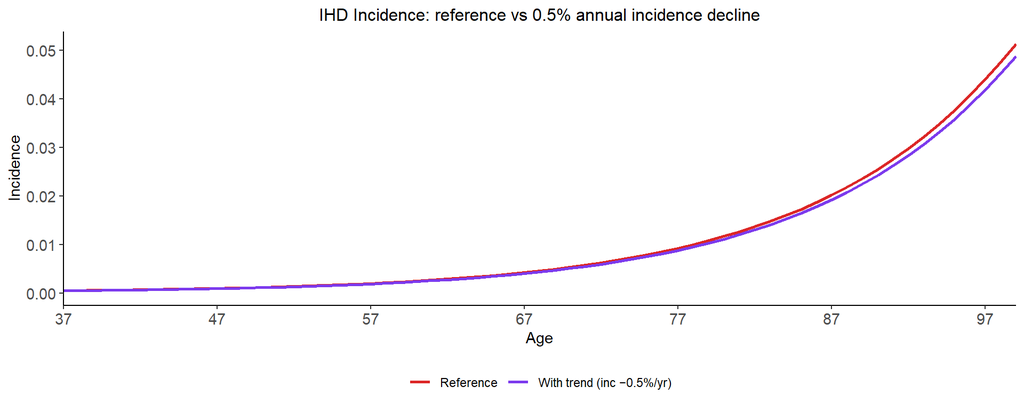

```r
dis_trend_ishd <- RunDisease(
  in_data      = mslt_general,
  in_sex       = "female",
  in_mid_age   = 37,
  in_disease   = "ishd",
  inc_trend    = 0.5,   # 0.5% annual decline in incidence, compounding
  cf_trend     = NA,
  inc_trend_years = 10,
  scenario_inc = 0,
  scenario_cf  = 0
) %>% mutate(label = "With trend (inc −0.5%/yr)")

# Compare IHD prevalence reference vs trend
dis_ishd_compare <- bind_rows(dis_ref_ishd, dis_trend_ishd)

ggplot(dis_ishd_compare, aes(x = age, y = incidence_disease, colour = label)) +
  geom_line(linewidth = 1) +
  scale_colour_manual(values = c("Reference" = "#DC2626",
                                 "With trend (inc −0.5%/yr)" = "#7C3AED")) +
  scale_x_continuous(limits = c(37, 99), breaks = seq(37, 99, 10), expand = c(0, 0)) +
  labs(title = "IHD Incidence: reference vs 0.5% annual incidence decline",
       x = "Age", y = "Incidence", colour = NULL) +
  theme_classic() +
  theme(plot.title = element_text(size = 12, hjust = 0.5),
        axis.text = element_text(size = 11), axis.title = element_text(size = 11),
        legend.position = "bottom")
```

## 4.4 Example 1 — 5% reduction in incidence

**Question:** What happens to disease prevalence and disease-specific mortality if incidence falls by 5% permanently at all ages?

```r
# Run 5% scenario for all three diseases
dis_sc5_ishd <- RunDisease(
  in_data      = mslt_general,
  in_sex       = "female",
  in_mid_age   = 37,
  in_disease   = "ishd",
  inc_trend    = NA,
  cf_trend     = NA,
  scenario_inc = 0.05,    # 5% one-off reduction in incidence
  scenario_cf  = 0
) %>% mutate(label = "5% incidence reduction")

dis_sc5_copd <- RunDisease(
  in_data      = mslt_general,
  in_sex       = "female",
  in_mid_age   = 37,
  in_disease   = "copd",
  inc_trend    = NA,
  cf_trend     = NA,
  scenario_inc = 0.05,
  scenario_cf  = 0
) %>% mutate(label = "5% incidence reduction")

dis_sc5_dmt2 <- RunDisease(
  in_data      = mslt_general,
  in_sex       = "female",
  in_mid_age   = 37,
  in_disease   = "dmt2",
  inc_trend    = NA,
  cf_trend     = NA,
  scenario_inc = 0.05,
  scenario_cf  = 0
) %>% mutate(label = "5% incidence reduction")
```

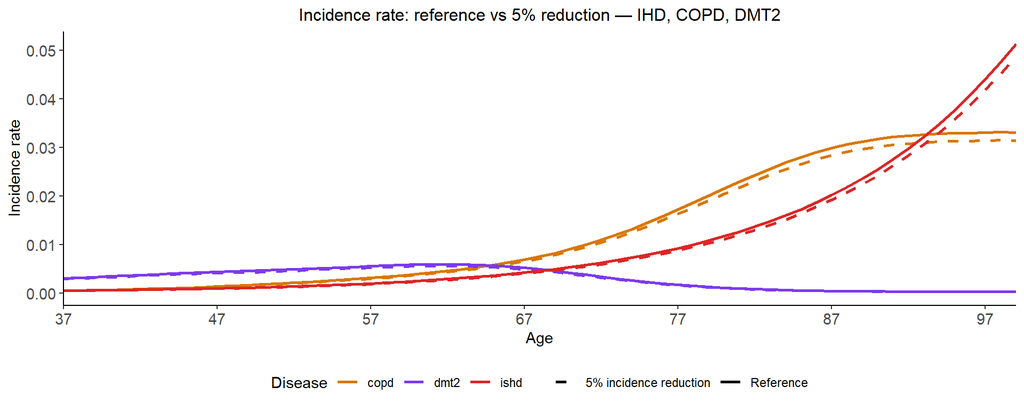

```r
dis_all_sc5 <- bind_rows(
  dis_ref_ishd, dis_sc5_ishd,
  dis_ref_copd, dis_sc5_copd,
  dis_ref_dmt2, dis_sc5_dmt2
)

ggplot(dis_all_sc5, aes(x = age, y = incidence_disease, colour = disease, linetype = label)) +
  geom_line(linewidth = 1) +
  scale_x_continuous(limits = c(37, 99), breaks = seq(37, 99, 10), expand = c(0, 0)) +
  scale_colour_manual(values = c("ishd" = "#DC2626", "copd" = "#D97706", "dmt2" = "#7C3AED")) +
  scale_linetype_manual(values = c("Reference" = "solid", "5% incidence reduction" = "dashed")) +
  labs(title = "Incidence rate: reference vs 5% reduction — IHD, COPD, DMT2",
       x = "Age", y = "Incidence rate", colour = "Disease", linetype = NULL) +
  theme_classic() +
  theme(plot.title = element_text(size = 12, hjust = 0.5),
        axis.text = element_text(size = 11), axis.title = element_text(size = 11),
        legend.position = "bottom")
```

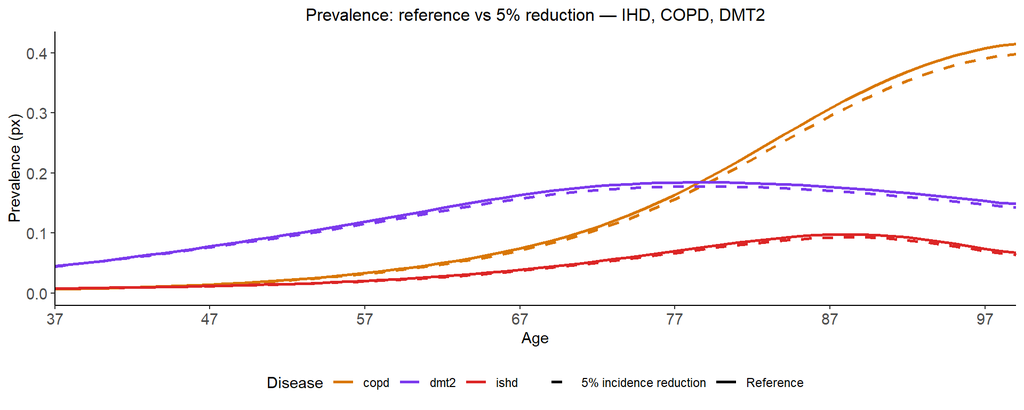

```r
# Prevalence (px) plot
ggplot(dis_all_sc5, aes(x = age, y = px, colour = disease, linetype = label)) +
  geom_line(linewidth = 1) +
  scale_x_continuous(limits = c(37, 99), breaks = seq(37, 99, 10), expand = c(0, 0)) +
  scale_colour_manual(values = c("ishd" = "#DC2626", "copd" = "#D97706", "dmt2" = "#7C3AED")) +
  scale_linetype_manual(values = c("Reference" = "solid", "5% incidence reduction" = "dashed")) +
  labs(title = "Prevalence: reference vs 5% reduction — IHD, COPD, DMT2",
       x = "Age", y = "Prevalence (px)", colour = "Disease", linetype = NULL) +
  theme_classic() +
  theme(plot.title = element_text(size = 12, hjust = 0.5),
        axis.text = element_text(size = 11), axis.title = element_text(size = 11),
        legend.position = "bottom")
```

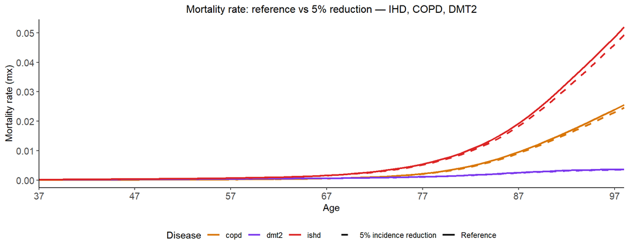

```r
# Mortality (mx) plot
ggplot(dis_all_sc5, aes(x = age, y = mx, colour = disease, linetype = label)) +
  geom_line(linewidth = 1) +
  scale_x_continuous(limits = c(37, 98), breaks = seq(37, 98, 10), expand = c(0, 0)) +
  scale_colour_manual(values = c("ishd" = "#DC2626", "copd" = "#D97706", "dmt2" = "#7C3AED")) +
  scale_linetype_manual(values = c("Reference" = "solid", "5% incidence reduction" = "dashed")) +
  labs(title = "Mortality rate: reference vs 5% reduction — IHD, COPD, DMT2",
       x = "Age", y = "Mortality rate (mx)", colour = "Disease", linetype = NULL) +
  theme_classic() +
  theme(plot.title = element_text(size = 12, hjust = 0.5),
        axis.text = element_text(size = 11), axis.title = element_text(size = 11),
        legend.position = "bottom")
```

**Key teaching point — disease scenario vs life table scenario**

`scenario_inc = 0.05` in `RunDisease()` reduces incidence by 5% at every age. The full effect on life years only materialises inside `CalculationModel()`, which propagates the disease mortality and disability reduction into the general life table. The disease table alone shows you the epidemiological change; the MSLT shows you the life-years consequence.

## 4.5 Complete MSLT — Physical Activity and Diseases

The full proportional multi-state life table (Barendregt et al. 1998) combines:

1. A **general life table** tracking total survival (from `RunLifeTable()`)
2. **Disease sections** for each modelled condition (from `RunDisease()`)
3. **Feedback**: disease-specific mortality from step 2 modifies total `mx` in step 1 and alternatively `mx` is modified directly by the PIF

`CalculationModel()` runs all three components simultaneously and returns differences (scenario − reference) in life years, health-adjusted life years, and disease-specific incidence and mortality.

## 4.6 Example 1 — PA scenario with disease-specific PIFs

**Question:** What is the gain in life years and health-adjusted life years from PA increase from the Pedestrian scenario, modelled through disease-specific incidence reductions for IHD and type 2 diabetes?

The pathway is:

$$\text{PA distribution} \xrightarrow{\text{dose-response}} \text{RR by disease} \xrightarrow{\text{PIF per disease}} \Delta\text{incidence} \xrightarrow{\text{MSLT}} \Delta\text{life years}$$

### 4.6.1 Step 1 — Assign disease-specific RRs

```r
# Disease names as used by the drpa package
diseases_mslt <- c(
  "coronary-heart-disease",
  # "chronic-obstructive-pulmonary-disease", not a physical activity disease
  "diabetes",
  "all-cause-mortality"          # also included for the life table component
)

# Assign RRs for reference and counterfactual PA distributions
bogota_ref  <- bogota_mmets_long %>%
  filter(scenario == "baseline") %>%
  rename(mmet = total_mmets) %>%
  assignPA_RRs(., diseases = diseases_mslt, mmet_col = "mmet")

bogota_scen <- bogota_mmets_long %>%
  filter(scenario == "sc_ped") %>%
  rename(mmet = total_mmets) %>%
  assignPA_RRs(., diseases = diseases_mslt, mmet_col = "mmet")

# Quick sanity check — all RRs should be <= 1 (PA is protective)
rr_cols <- grep("^rr_", names(bogota_ref), value = TRUE)
cat("Reference RR ranges:\n")
```

```
Reference RR ranges:
```

```r
for (col in rr_cols) {
  cat(sprintf("  %-60s min=%.4f  mean=%.4f\n",
              col, min(bogota_ref[[col]]), mean(bogota_ref[[col]])))
}
```

```
  rr_PHYSICAL_ACTIVITY_coronary-heart-disease                  min=0.7441  mean=0.8533
  rr_PHYSICAL_ACTIVITY_diabetes                                min=0.6387  mean=0.8026
  rr_PHYSICAL_ACTIVITY_all-cause-mortality                     min=0.6755  mean=0.8053
```

```r
cat("Scenario RR ranges:\n")
```

```
Scenario RR ranges:
```

```r
for (col in rr_cols) {
  cat(sprintf("  %-60s min=%.4f  mean=%.4f\n",
              col, min(bogota_scen[[col]]), mean(bogota_scen[[col]])))
}
```

```
  rr_PHYSICAL_ACTIVITY_coronary-heart-disease                  min=0.7441  mean=0.8524
  rr_PHYSICAL_ACTIVITY_diabetes                                min=0.6387  mean=0.8011
  rr_PHYSICAL_ACTIVITY_all-cause-mortality                     min=0.6755  mean=0.8044
```

### 4.6.2 Step 2 — Calculate disease-specific PIFs

```r
pif_inc <- calculate_pif(pop_ref  = bogota_ref,
                                   pop_scen = bogota_scen)
pifs_inc        <- pif_inc$pif_table %>% rename(disease = cause)

cat("PIFs by disease for incidence, sex and age group:\n")
```

```
PIFs by disease for incidence, sex and age group:
```

```r
print(pifs_inc  %>% arrange(disease, sex, age_cat), n = Inf)
```

```
# A tibble: 66 × 7
   sex    age_cat disease                    n sum_rr_ref sum_rr_scen      pif
   <chr>  <chr>   <chr>                  <int>      <dbl>       <dbl>    <dbl>
 1 female 15-19   all_cause_mortality     6650      6081.       6080. 0.000139
 2 female 20-24   all_cause_mortality     5235      3818.       3816. 0.000642
 3 female 25-29   all_cause_mortality     5185      3763.       3760. 0.000708
 4 female 30-34   all_cause_mortality     5312      4227.       4220. 0.00171
 5 female 35-39   all_cause_mortality     5298      4192.       4185. 0.00167
 6 female 40-44   all_cause_mortality     5135      4077.       4070. 0.00173
 7 female 45-49   all_cause_mortality     5322      4230.       4223. 0.00159
 8 female 50-54   all_cause_mortality     4687      3796.       3787. 0.00238
 9 female 55-59   all_cause_mortality     4823      3913.       3905. 0.00223
10 female 60-64   all_cause_mortality     3903      3233.       3229. 0.00128
11 female 65-69   all_cause_mortality     4043      3348.       3343. 0.00150
12 male   15-19   all_cause_mortality     6671      6116.       6115. 0.000195
```

[output cut: 54 more lines]

### 4.6.3 Step 3 — Run the complete MSLT

First, assess whether the model is working properly. It is expected that without an interventions or difference in trends the model should produce zero outputs since it compares exactly the same sets of MSLTs for the same population cohort.

```r
# ── Validation: run with zero scenario — all differences must be zero ─────────
output_test <- CalculationModel(
  in_data      = mslt_general,
  in_sex       = "female",
  in_mid_age   = 37,
  mx_trend     = NA,
  in_disease   = c("ishd", "copd", "dmt2"),
  inc_trend    = NA,
  cf_trend     = NA,
  scenario_inc = 0,
  scenario_cf  = 0
)

cat("Validation checks (all must be zero):\n")
```

```
Validation checks (all must be zero):
```

```r
cat(sprintf("  sum(Lx_diff):              %.6f\n", sum(output_test$Lx_diff)))
```

```
  sum(Lx_diff):              0.000000
```

```r
cat(sprintf("  sum(Lwx_diff):             %.6f\n", sum(output_test$Lwx_diff)))
```

```
  sum(Lwx_diff):             0.000000
```

```r
cat(sprintf("  sum(inc_num_diff_ishd):    %.6f\n", sum(output_test$inc_num_diff_ishd)))
```

```
  sum(inc_num_diff_ishd):    0.000000
```

```r
cat(sprintf("  sum(inc_num_diff_copd):    %.6f\n", sum(output_test$inc_num_diff_copd)))
```

```
  sum(inc_num_diff_copd):    0.000000
```

```r
cat(sprintf("  sum(inc_num_diff_dmt2):    %.6f\n", sum(output_test$inc_num_diff_dmt2)))
```

```
  sum(inc_num_diff_dmt2):    0.000000
```

Second, assess whether the modeled prevalence and mortality aligns with the input data for the selected diseases.

```r
# Compare baseline (no intervention) model outputs with GBD data
# Load GBD data for comparison
gbd_data <- read_csv("data/lecture_5_6/gbd_mslt_2019_colombia.csv")

# Filter GBD data
gbd_prev <- gbd_data %>%
  filter(measure_name == "Prevalence",
         metric_name == "Rate",
         sex_name == "Female") %>%
  mutate(age = case_when(
    age_name == "95+ years" ~ 95,
    TRUE ~ as.integer(str_extract(age_name, "^\\d+"))
  )) %>%
  mutate(disease = case_match(cause_name,
    "Ischemic heart disease" ~ "ishd",
    "Chronic obstructive pulmonary disease" ~ "copd",
    "Diabetes mellitus type 2" ~ "dmt2",
    .default = NA_character_
  )) %>%
  filter(!is.na(age), !is.na(disease), age >= 15) %>%
  dplyr::select(age, disease, gbd_px = val)

gbd_mort <- gbd_data %>%
  filter(measure_name == "Deaths",
         metric_name == "Rate",
         sex_name == "Female") %>%
  mutate(age = case_when(
    age_name == "95+ years" ~ 95,
    TRUE ~ as.integer(str_extract(age_name, "^\\d+"))
  )) %>%
  mutate(disease = case_match(cause_name,
    "Ischemic heart disease" ~ "ishd",
    "Chronic obstructive pulmonary disease" ~ "copd",
    "Diabetes mellitus type 2" ~ "dmt2",
    .default = NA_character_
  )) %>%
  filter(!is.na(age), !is.na(disease)) %>%
  dplyr::select(age, disease, gbd_mx = val)

# Run baseline disease tables for comparison
dis_ref_ishd <- RunDisease(
  in_data      = mslt_general,
  in_sex       = "female",
  in_mid_age   = 37,
  in_disease   = "ishd",
  scenario_inc = 0,
  scenario_cf  = 0
) %>% mutate(disease = "ishd")

dis_ref_copd <- RunDisease(
  in_data      = mslt_general,
  in_sex       = "female",
  in_mid_age   = 37,
  in_disease   = "copd",
  scenario_inc = 0,
  scenario_cf  = 0
) %>% mutate(disease = "copd")

dis_ref_dmt2 <- RunDisease(
  in_data      = mslt_general,
  in_sex       = "female",
  in_mid_age   = 37,
  in_disease   = "dmt2",
  scenario_inc = 0,
  scenario_cf  = 0
) %>% mutate(disease = "dmt2")

# Merge model outputs with GBD data
dis_all_ref <- bind_rows(dis_ref_ishd, dis_ref_copd, dis_ref_dmt2) %>%
  filter(age >= 37, age <= 90) %>%
  left_join(gbd_prev, by = c("age", "disease")) %>%
  left_join(gbd_mort, by = c("age", "disease")) %>%
  mutate(
    model_px = px * 100000,
    model_mx = mx * 100000
  )

# Print comparison summary
cat("\n=== Model vs GBD Comparison (baseline, no intervention) ===\n")
```

```
=== Model vs GBD Comparison (baseline, no intervention) ===
```

```r
for (dis in c("ishd", "copd", "dmt2")) {
  d <- dis_all_ref %>% filter(disease == dis)
  cat("\n", toupper(dis), ":\n")
  cat("  Prevalence - Model range:", round(range(d$model_px, na.rm = TRUE), 1), "\n")
  cat("  Prevalence - GBD range:  ", round(range(d$gbd_px, na.rm = TRUE), 1), "\n")
  cat("  Prevalence - Correlation:", round(cor(d$model_px, d$gbd_px, use = "complete.obs"), 3), "\n")
  cat("  Mortality - Model range: ", round(range(d$model_mx, na.rm = TRUE), 1), "\n")
  cat("  Mortality - GBD range:   ", round(range(d$gbd_mx, na.rm = TRUE), 1), "\n")
  cat("  Mortality - Correlation: ", round(cor(d$model_mx, d$gbd_mx, use = "complete.obs"), 3), "\n")
}
```

```
 ISHD :
  Prevalence - Model range: 767.5 9780.2
  Prevalence - GBD range:   1024.1 12343.8
  Prevalence - Correlation: 0.988
  Mortality - Model range:  19.2 2691.2
  Mortality - GBD range:    7.2 3405
  Mortality - Correlation:  1

 COPD :
  Prevalence - Model range: 651.4 34668.4
  Prevalence - GBD range:   877.2 41330.2
  Prevalence - Correlation: 0.999
  Mortality - Model range:  7.2 1339.4
  Mortality - GBD range:    0.8 1689.7
  Mortality - Correlation:  1

 DMT2 :
  Prevalence - Model range: 4458.8 18446.8
  Prevalence - GBD range:   5938.8 18857.2
  Prevalence - Correlation: 0.973
  Mortality - Model range:  12.5 299.4
  Mortality - GBD range:    2.7 319.8
  Mortality - Correlation:  0.996
```

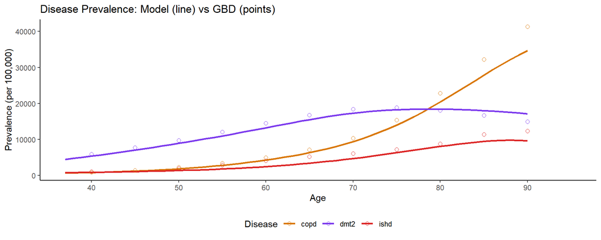

```r
# Plot comparison
p_px <- ggplot(dis_all_ref %>% filter(age <= 90), aes(x = age)) +
  geom_line(aes(y = model_px, colour = disease), linewidth = 1) +
  geom_point(aes(y = gbd_px, colour = disease), shape = 1, size = 2, na.rm = TRUE) +
  scale_x_continuous(limits = c(37, 95), breaks = seq(40, 90, 10)) +
  scale_colour_manual(values = c("ishd" = "#DC2626", "copd" = "#D97706", "dmt2" = "#7C3AED")) +
  labs(title = "Disease Prevalence: Model (line) vs GBD (points)",
       x = "Age", y = "Prevalence (per 100,000)", colour = "Disease") +
  theme_classic() + theme(legend.position = "bottom")

p_mx <- ggplot(dis_all_ref %>% filter(age < 99), aes(x = age)) +
  geom_line(aes(y = model_mx, colour = disease), linewidth = 1) +
  geom_point(aes(y = gbd_mx, colour = disease), shape = 1, size = 2, na.rm = TRUE) +
  scale_x_continuous(limits = c(37, 95), breaks = seq(40, 90, 10)) +
  scale_colour_manual(values = c("ishd" = "#DC2626", "copd" = "#D97706", "dmt2" = "#7C3AED")) +
  labs(title = "Disease Mortality: Model (line) vs GBD (points)",
       x = "Age", y = "Mortality (per 100,000)", colour = "Disease") +
  theme_classic() + theme(legend.position = "bottom")

print(p_px)
```

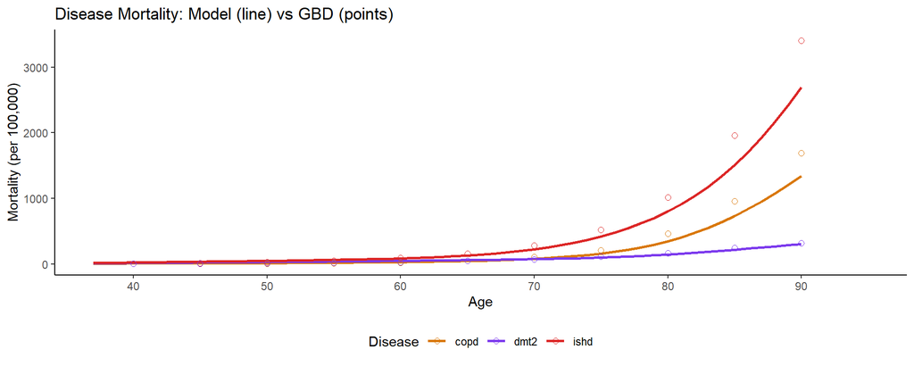

```r
print(p_mx)
```

```r
# Create age-specific PIF dataframes for diseases and all-cause (female)
# Note: column names must contain "inc" for scenario_inc, "cf" for scenario_cf,
# and "mort"/"all_cause"/"pif" for scenario (mortality)
pif_ishd_by_age <- pifs_inc %>%
  dplyr::filter(disease == "coronary_heart_disease", sex == "female") %>%
  dplyr::arrange(age_cat) %>%
  dplyr::select(age_cat, sex, pif_inc_ishd = pif)

pif_dmt2_by_age <- pifs_inc %>%
  dplyr::filter(disease == "diabetes", sex == "female") %>%
  dplyr::arrange(age_cat) %>%
  dplyr::select(age_cat, sex, pif_inc_dmt2 = pif)

pif_acm_by_age <- pifs_inc %>%
  dplyr::filter(disease == "all_cause_mortality", sex == "female") %>%
  dplyr::arrange(age_cat) %>%
  dplyr::select(age_cat, sex, pif_mort = pif)

# ── Scenario A: disease-specific mortality pathway (use_disease_mx = TRUE)
# Disease PIFs → reduced incidence → reduced disease mortality → reduced all-cause mx
# Using dataframes for scenario_inc (age_cat with PIFs, expanded to single ages in RunDisease)
output_mslt_dis <- CalculationModel(
  in_data        = mslt_general,
  in_sex         = "female",
  in_mid_age     = 37,
  mx_trend       = NA,
  in_disease     = c("ishd", "copd", "dmt2"),
  inc_trend      = NA,
  cf_trend       = NA,
  scenario       = 0,
  scenario_inc   = list(ishd = pif_ishd_by_age, copd = 0, dmt2 = pif_dmt2_by_age),
  scenario_cf    = 0,
  use_disease_mx = TRUE
)

# ── Scenario B: all-cause mortality pathway (use_disease_mx = FALSE)
# Same disease incidence changes, but age-specific all-cause PIF applied directly to mx
# scenario as dataframe applies age-specific PIF to all-cause mx
output_mslt_acm <- CalculationModel(
  in_data        = mslt_general,
  in_sex         = "female",
  in_mid_age     = 37,
  mx_trend       = NA,
  in_disease     = c("ishd", "copd", "dmt2"),
  inc_trend      = NA,
  cf_trend       = NA,
  scenario       = pif_acm_by_age,  # age-specific all-cause PIF as dataframe
  scenario_inc   = list(ishd = pif_ishd_by_age, copd = 0, dmt2 = pif_dmt2_by_age),
  scenario_cf    = 0,
  use_disease_mx = FALSE
)

write_csv(output_mslt_dis, "outputs/lecture_5_6/mslt_pa_disease_pifs.csv")
write_csv(output_mslt_acm, "outputs/lecture_5_6/mslt_pa_allcause_pif.csv")
```

### 4.6.4 Step 5 — Results

Table: MSLT results comparison. Positive values = cases/deaths prevented; negative = cases/deaths increased.

[output not shown]

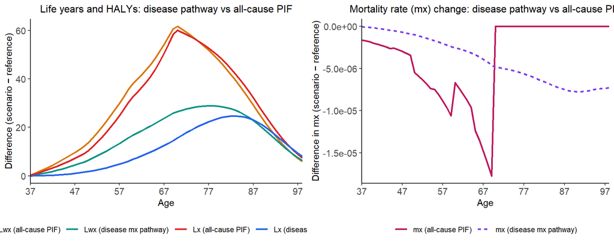

```r
# ── Life years and HALYs comparison: both MSLT scenarios ───────────────────────
ly_compare <- bind_rows(
  output_mslt_dis %>%
    transmute(age, sex,
              measure = "Lx (disease mx pathway)",    value = Lx_diff),
  output_mslt_dis %>%
    transmute(age, sex,
              measure = "Lwx (disease mx pathway)",   value = Lwx_diff),
  output_mslt_acm %>%
    transmute(age, sex,
              measure = "Lx (all-cause PIF)",         value = Lx_diff),
  output_mslt_acm %>%
    transmute(age, sex,
              measure = "Lwx (all-cause PIF)",        value = Lwx_diff)
)

p_ly <- ggplot(ly_compare, aes(x = age, y = value, colour = measure)) +
  geom_line(linewidth = 1) +
  scale_x_continuous(limits = c(37, 98), breaks = seq(37, 98, 10), expand = c(0, 0)) +
  scale_colour_manual(values = c(
    "Lx (disease mx pathway)"  = "#2563EB",
    "Lwx (disease mx pathway)" = "#0D9488",
    "Lx (all-cause PIF)"       = "#DC2626",
    "Lwx (all-cause PIF)"      = "#D97706"
  )) +
  labs(title = "Life years and HALYs: disease pathway vs all-cause PIF",
       x = "Age", y = "Difference (scenario − reference)", colour = NULL) +
  theme_classic() +
  theme(plot.title = element_text(size = 12, hjust = 0.5),
        axis.text = element_text(size = 11), axis.title = element_text(size = 11),
        legend.position = "bottom")

# ── Mortality (mx) comparison: both MSLT scenarios ────────────────────────────
mx_compare <- bind_rows(
  output_mslt_dis %>%
    transmute(age, sex,
              measure = "mx (disease mx pathway)",    value = mx_diff),
  output_mslt_acm %>%
    transmute(age, sex,
              measure = "mx (all-cause PIF)",          value = mx_diff)
)

p_mx <- ggplot(mx_compare, aes(x = age, y = value, colour = measure, linetype = measure)) +
  geom_line(linewidth = 1) +
  scale_x_continuous(limits = c(37, 98), breaks = seq(37, 98, 10), expand = c(0, 0)) +
  scale_colour_manual(values = c(
    "mx (disease mx pathway)"  = "#7C3AED",
    "mx (all-cause PIF)"       = "#BE185D"
  )) +
  labs(title = "Mortality rate (mx) change: disease pathway vs all-cause PIF",
       x = "Age", y = "Difference in mx (scenario − reference)", colour = NULL, linetype = NULL) +
  theme_classic() +
  theme(plot.title = element_text(size = 12, hjust = 0.5),
        axis.text = element_text(size = 11), axis.title = element_text(size = 11),
        legend.position = "bottom")

gridExtra::grid.arrange(p_ly, p_mx, ncol = 2)
```

## 4.7 Comparing all scenarios

| Approach | How mx changes | use_disease_mx | Gain Lx | Gain Lwx | IHD cases prevented | COPD cases prevented | DMT2 cases prevented | Competing risks |
| --- | --- | --- | --- | --- | --- | --- | --- | --- |
| 1. Simple life table — all-cause PIF | PIF × all-cause mx directly | — | 1,764 | 1,350 | — | — | — | No |
| 2. MSLT — disease PIFs → disease mx → general LT | Incidence ↓ → disease mx ↓ → total mx ↓ | TRUE | 715 | 999 | -18 | 10 | -114 | Yes |
| 3. MSLT — disease PIFs + all-cause PIF on mx | Same incidence changes; mx × (1 − pif_acm) | FALSE | 1,764 | 1,824 | -12 | 20 | -111 | Yes |

**Interpreting the three-way comparison**

If approach 2 and approach 3 give similar life-year totals, it suggests the disease-mortality pathway accounts for most of the all-cause PIF in this population. If approach 3 is substantially larger, there are important PA→mortality pathways beyond the three modelled diseases.

## 4.8 Exercise — extend to multiple cohorts and diseases

```r
# Run the full MSLT pipeline for males cohort aged 50-54 and females cohort aged 35-39
# Compare: how do disease-specific gains differ by sex and entry age?

for (sex_i in c("female", "male")) {
  for (age_i in c(37, 52)) {

    age_cat_i <- case_when(age_i == 37 ~ "35-39", age_i == 52 ~ "50-54")

    pif_ishd_i <- pifs_inc %>%
      filter(disease == "coronary_heart_disease",
             sex == sex_i, age_cat == age_cat_i) %>%
      pull(pif)
    pif_dmt2_i <- pifs_inc %>%
      filter(disease == "diabetes",
             sex == sex_i, age_cat == age_cat_i) %>%
      pull(pif)

    out_i <- CalculationModel(
      in_data      = mslt_general,
      in_sex       = sex_i,
      in_mid_age   = age_i,
      mx_trend     = NA,
      in_disease   = c("ishd", "copd", "dmt2"),
      inc_trend    = NA,
      cf_trend     = NA,
      scenario_inc = c(ishd = pif_ishd_i, copd = 0, dmt2 = pif_dmt2_i),
      scenario_cf  = 0
    )

    cat(sprintf(
      "%s aged %d | Lx gain: %s | Lwx gain: %s | IHD cases: %s\n",
      sex_i, age_i,
      format(round(sum(out_i$Lx_diff)),  big.mark = ","),
      format(round(sum(out_i$Lwx_diff)), big.mark = ","),
      format(round(abs(sum(out_i$inc_num_diff_ishd))), big.mark = ",")
    ))
  }
}
```

## 4.9 Comparison with CRA approach

A Comparative Risk Assessment (CRA) applies PIFs directly to baseline burden without the multi-state life table dynamics. It estimates effects at a single point in time (year 1), while MSLT captures effects over the full lifetime.

CRA vs MSLT: Year 1 and lifetime effects

| Measure | CRA | MSLT (disease mx) | MSLT (direct PIF) |
| --- | --- | --- | --- |
| Year 1: IHD cases | 0 | 0 | 0 |
| Year 1: COPD cases | — | 0 | 0 |
| Year 1: DMT2 cases | 3 | -3 | -3 |
| Year 1: deaths prevented | 1 | 0 | -1 |
| Lifetime: IHD cases | — | -18 | -12 |
| Lifetime: COPD cases | — | 10 | 20 |
| Lifetime: DMT2 cases | — | -114 | -111 |
| Lifetime: deaths prevented | — | 0 | 0 |
| Lifetime: life years gained | 24 | 715 | 1,764 |

- **CRA**: deaths prevented in year 1 × remaining life expectancy = lifetime life years
- **MSLT (disease mx)**: incidence ↓ → disease mx ↓ → total mx ↓
- **MSLT (direct PIF)**: same incidence changes; mx × (1 − pif_acm)